# Plotting made fun with Seaborn

To analyse a set of data using Python, we make use of Matplotlib, a widely implemented 2D plotting library. Likewise, Seaborn is a visualization library in Python. It is built on top of Matplotlib.

**Important Features of Seaborn**

Seaborn is built on top of Python’s core visualization library Matplotlib. It is meant to serve as a complement, and not a replacement. However, Seaborn comes with some very important features. Let us see a few of them here. The features help in −

- Built in themes for styling matplotlib graphics
- Visualizing univariate and bivariate data
- Fitting in and visualizing linear regression models
- Plotting statistical time series data
- Seaborn works well with NumPy and Pandas data structures
- Effective visualization of categorical data

In most cases, you will still use Matplotlib for simple plotting. The knowledge of Matplotlib is recommended to tweak Seaborn’s default plots.

**Seaborn Vs Matplotlib**

It is summarized that if Matplotlib “tries to make easy things easy and hard things possible”, Seaborn tries to make a well-defined set of hard things easy too.”

Seaborn helps resolve the two major problems faced by Matplotlib; the problems are −

Default Matplotlib parameters Working with data frames As Seaborn compliments and extends Matplotlib, the learning curve is quite gradual. If you know Matplotlib, you are already half way through Seaborn.

```python
# !pip install seaborn
```

```python
import matplotlib.pyplot as plt
import seaborn as sns
%matplotlib inline
```

**Loading a buit-in dataset `tips` which comes with the package**

```python
tips = sns.load_dataset('tips')

#lets have a look at the data
tips.head()
```

|  | total_bill | tip | sex | smoker | day | time | size |
| --- | --- | --- | --- | --- | --- | --- | --- |
| 0 | 16.99 | 1.01 | Female | No | Sun | Dinner | 2 |
| 1 | 10.34 | 1.66 | Male | No | Sun | Dinner | 3 |
| 2 | 21.01 | 3.50 | Male | No | Sun | Dinner | 3 |
| 3 | 23.68 | 3.31 | Male | No | Sun | Dinner | 2 |
| 4 | 24.59 | 3.61 | Female | No | Sun | Dinner | 4 |

## Barplot and Countplot

These very similar plots allow you to get aggregate data off a categorical feature in your data. **Barplot** is a general plot that allows you to aggregate the categorical data based off some function, by default the mean. Now let's discuss using seaborn to plot categorical data.

### barplot

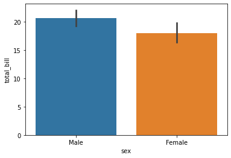

```python
sns.barplot(x='sex',y ='total_bill',data=tips) #y axis is numeric, x axis is categorical
plt.show()
```

### countplot

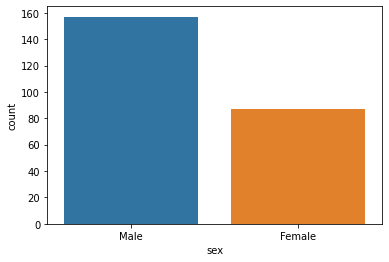

```python
sns.countplot(x='sex',data=tips); # counts no. of occurences thats why we give only x value
```

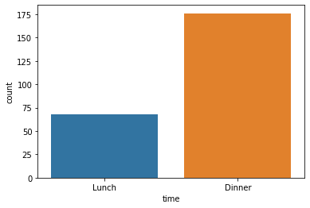

```python
sns.countplot(x='time',data=tips); # counts no. of occurences thats why we give only x value
```

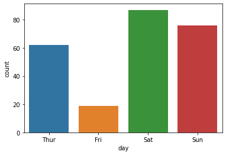

```python
sns.countplot(x='day',data=tips); # counts no. of occurences thats why we give only x value
```

## factorplot

factorplot is the most general form of a categorical plot. It can take in a **kind** parameter to adjust the plot type:

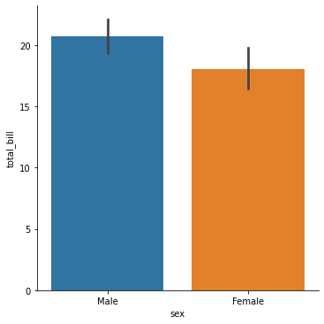

```python
sns.factorplot(x='sex',y='total_bill',data=tips,kind='bar') # input 'kind'  defines the type of graph
```

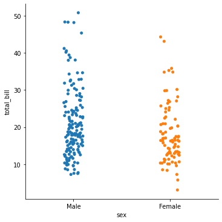

```python
sns.factorplot(x='sex',y='total_bill',data=tips,kind='strip')
```

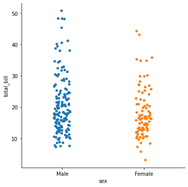

```python
sns.catplot(x='sex',y='total_bill',data=tips)
plt.show()
```

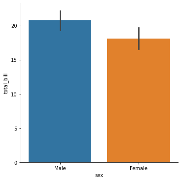

```python
sns.catplot(x='sex',y='total_bill',data=tips, kind = 'bar')
plt.show()
```

## Histogram

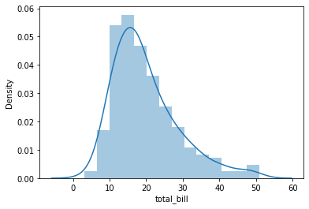

```python
sns.distplot(tips['total_bill'])
plt.show()
```

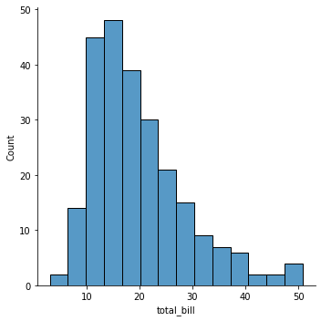

```python
sns.displot(tips['total_bill'])
plt.show()
```

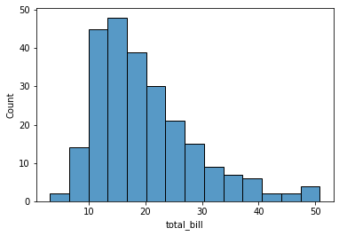

```python
sns.histplot(tips['total_bill'])
plt.show()
```

## Scatter Plot

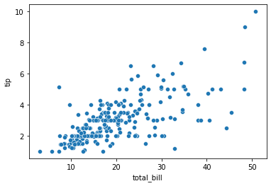

```python
sns.scatterplot(data=tips, x="total_bill", y="tip")
plt.show()
```

Assigning a variable to `hue` will map its levels to the color of the points:

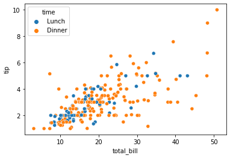

```python
sns.scatterplot(data=tips, x="total_bill", y="tip", hue="time")
plt.show()
```

Assigning the same variable to style will also vary the markers and create a more accessible plot:

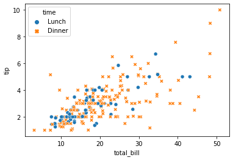

```python
sns.scatterplot(data=tips, x="total_bill", y="tip", hue="time", style="time")
plt.show()
```

Assigning hue and style to different variables will vary colors and markers independently:

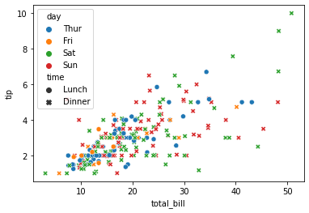

```python
sns.scatterplot(data=tips, x="total_bill", y="tip", hue="day", style="time")
plt.show()
```

## stripplot

The stripplot will draw a scatterplot where one variable is categorical.

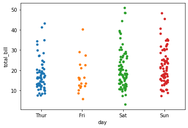

```python
sns.stripplot(x="day", y="total_bill", data=tips)
```

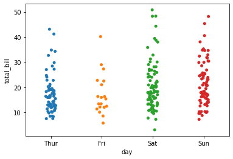

```python
sns.stripplot(x="day", y="total_bill", data=tips,jitter=True)
#Jitter=true shows seperate non repetitive observations
```

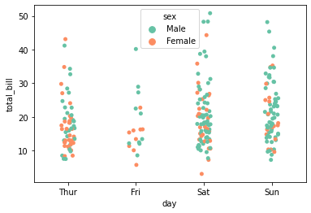

```python
sns.stripplot(x="day", y="total_bill", data=tips,jitter=True,hue='sex',palette='Set2')
```

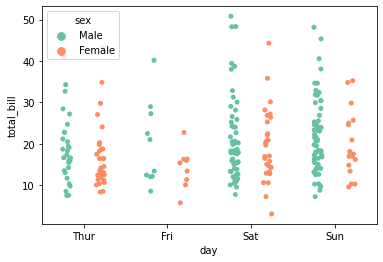

```python
sns.stripplot(x="day", y="total_bill", data=tips,jitter=True,hue='sex',palette='Set2',split=True)
```

### Another Example : `iris` dataset

```python
df = sns.load_dataset('iris')
df.head()
```

|  | sepal_length | sepal_width | petal_length | petal_width | species |
| --- | --- | --- | --- | --- | --- |
| 0 | 5.1 | 3.5 | 1.4 | 0.2 | setosa |
| 1 | 4.9 | 3.0 | 1.4 | 0.2 | setosa |
| 2 | 4.7 | 3.2 | 1.3 | 0.2 | setosa |
| 3 | 4.6 | 3.1 | 1.5 | 0.2 | setosa |
| 4 | 5.0 | 3.6 | 1.4 | 0.2 | setosa |

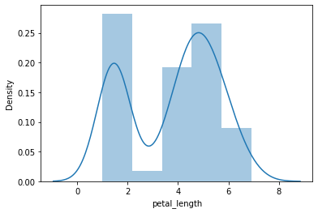

```python
sns.distplot(df['petal_length'])
plt.show()
```

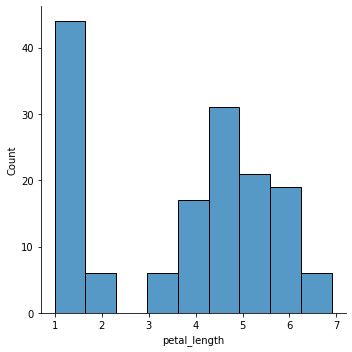

```python
sns.displot(df['petal_length']);
```

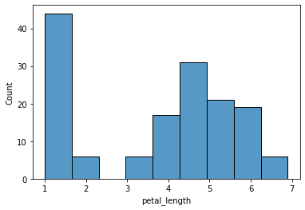

```python
sns.histplot(df['petal_length']);
```

## Multiple plots

The FacetGrid class is useful when you want to visualize the distribution of a variable or the relationship between multiple variables separately within subsets of your dataset.

A FacetGrid can be drawn with up to three dimensions: row, col, and hue. The first two have obvious correspondence with the resulting array of axes; think of the hue variable as a third dimension along a depth axis, where different levels are plotted with different colors.

`FacetGrid` object takes a dataframe as input and the names of the variables that will form the row, column, or hue dimensions of the grid. These variables should be categorical or discrete, and then the data at each level of the variable will be used for a facet along that axis.

For example, say we wanted to examine differences between lunch and dinner in the `tips` dataset:

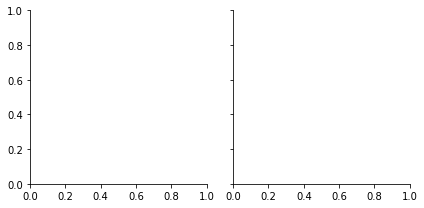

```python
tips = sns.load_dataset("tips") #loading dataset

g = sns.FacetGrid(tips, col="time")   # initializing the grid
```

*Initializing the grid like this sets up the matplotlib figure and axes, but doesn’t draw anything on them.*

**The main approach for visualizing data on this grid is with the `FacetGrid.map()` method.**

Provide it with a plotting function and the name(s) of variable(s) in the dataframe to plot. Let’s look at the distribution of tips in each of these subsets, using a histogram:

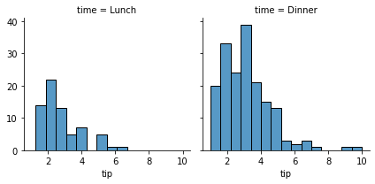

```python
g = sns.FacetGrid(tips, col="time")
g.map(sns.histplot, "tip");
```

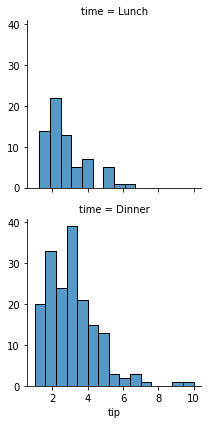

```python
g = sns.FacetGrid(tips, row="time")
g.map(sns.histplot, "tip");
```

**The size of the figure is set by providing the height of each facet, along with the aspect ratio:**

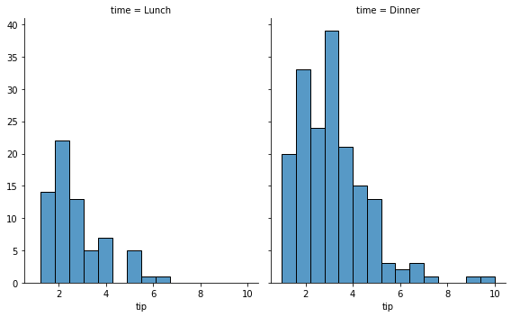

```python
g = sns.FacetGrid(tips, col="time", height = 5, aspect = 0.8)
g.map(sns.histplot, "tip");
```

**Another example of facetGrid with different variable as dimension**

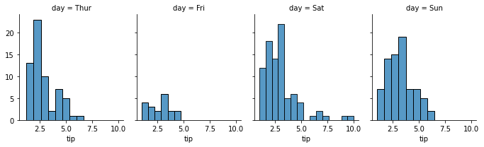

```python
g = sns.FacetGrid(tips, col="day", height = 3, aspect = 0.8)
g.map(sns.histplot, "tip");
```

There are several options for controlling the look of the grid.

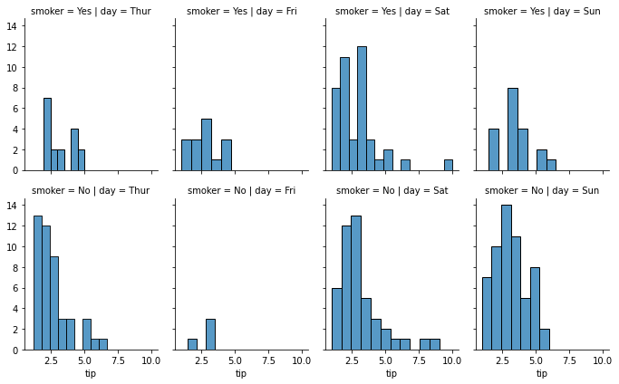

```python
g = sns.FacetGrid(tips, row="smoker", col="day", height = 3, aspect = 0.8)
g.map(sns.histplot, "tip");
```

This function will draw the figure and annotate the axes, hopefully producing a finished plot in one step.

**To make a relational plot, just pass multiple variable names.**

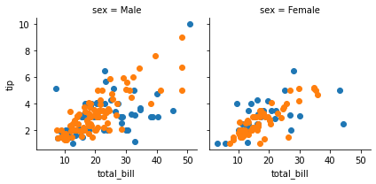

```python
g = sns.FacetGrid(tips, col = "sex", hue = "smoker")
g.map(plt.scatter, "total_bill", "tip")
plt.show()
```

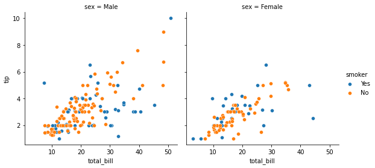

```python
g = sns.FacetGrid(tips, col="sex", hue="smoker",height = 4, aspect = 1)
g.map(sns.scatterplot, "total_bill", "tip")
g.add_legend();
```

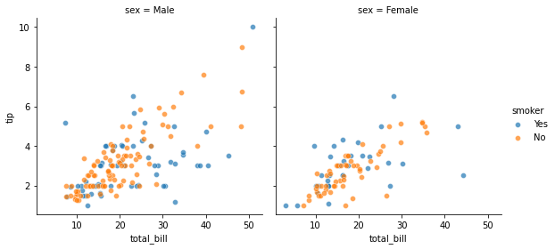

```python
g = sns.FacetGrid(tips, col="sex", hue="smoker",height = 4, aspect = 1)
g.map(sns.scatterplot, "total_bill", "tip", alpha = 0.7)
g.add_legend();
```

### PairGrid

In a PairGrid, each row and column is assigned to a different variable, so the resulting plot shows each pairwise relationship in the dataset. This style of plot is sometimes called a “scatterplot matrix”, as this is the most common way to show each relationship, but PairGrid is not limited to scatterplots.

Loading a buit-in dataset `iris` which comes with the package

```python
iris = sns.load_dataset('iris')
iris.head()
```

|  | sepal_length | sepal_width | petal_length | petal_width | species |
| --- | --- | --- | --- | --- | --- |
| 0 | 5.1 | 3.5 | 1.4 | 0.2 | setosa |
| 1 | 4.9 | 3.0 | 1.4 | 0.2 | setosa |
| 2 | 4.7 | 3.2 | 1.3 | 0.2 | setosa |
| 3 | 4.6 | 3.1 | 1.5 | 0.2 | setosa |
| 4 | 5.0 | 3.6 | 1.4 | 0.2 | setosa |

The basic usage of `Pairgrid` is very similar to `Facetgrid`. **First you initialize the grid, then you pass plotting function to a `map` method** and it will be called on each subplot.

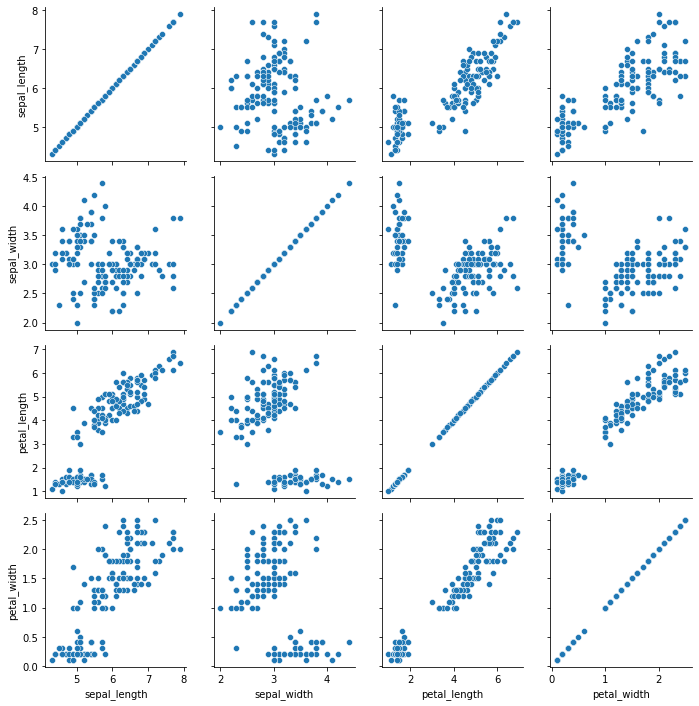

```python
#pairplot

iris = sns.load_dataset("iris")
g = sns.PairGrid(iris)
g.map(sns.scatterplot)
plt.show()
```

It’s possible to plot a different function on the diagonal to show the univariate distribution of the variable in each column. Note that the axis ticks won’t correspond to the count or density axis of this plot, though.

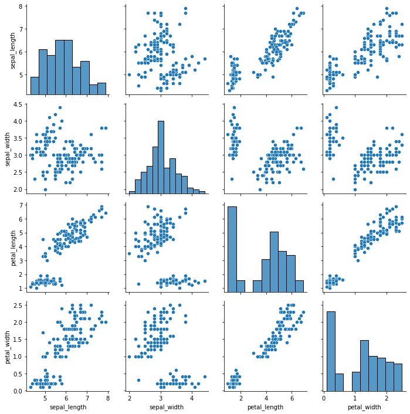

```python
g = sns.PairGrid(iris)
g.map_diag(sns.histplot)
g.map_offdiag(sns.scatterplot)
plt.show()
```

A very common way to use this plot colors the observations by a separate categorical variable. For example, the iris dataset has four measurements for each of three different species of iris flowers so you can see how they differ.

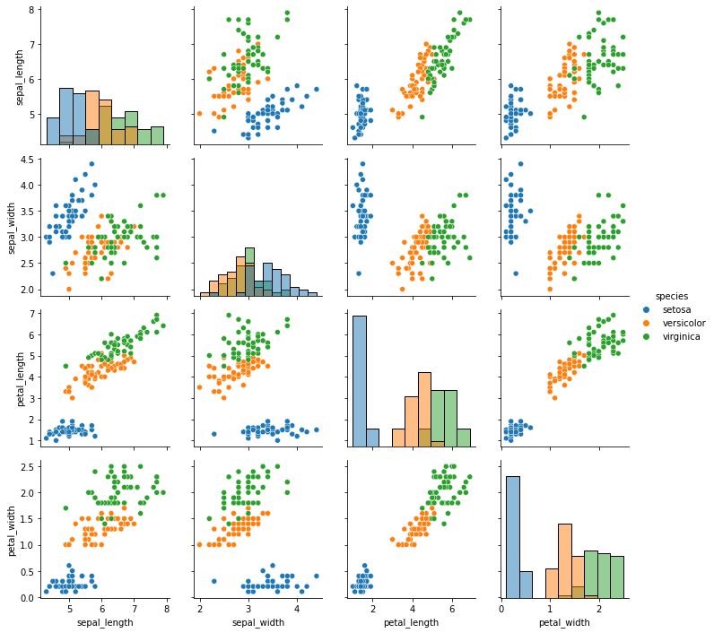

```python
g = sns.PairGrid(iris, hue="species")
g.map_diag(sns.histplot)
g.map_offdiag(sns.scatterplot)
g.add_legend()
plt.show()
```

**By default every numeric column in the dataset is used**, but you can focus on particular relationships if you want.

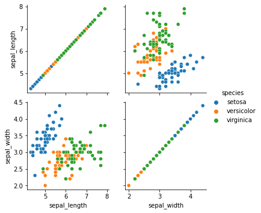

```python
g = sns.PairGrid(iris, vars=["sepal_length", "sepal_width"], hue="species")
g.map(sns.scatterplot)
g.add_legend()
plt.show()
```

## Seaborn Figure Styles

The interface for manipulating the styles is `set_style()`. Using this function you can set the theme of the plot. As per the latest updated version, below are the five themes available.

- darkgrid
- whitegrid
- dark
- white
- ticks

```python
import matplotlib.pyplot as plt
import seaborn as sns
%matplotlib inline
```

```python
tips = sns.load_dataset('tips')

#lets have a look at the data
tips.head()
```

|  | total_bill | tip | sex | smoker | day | time | size |
| --- | --- | --- | --- | --- | --- | --- | --- |
| 0 | 16.99 | 1.01 | Female | No | Sun | Dinner | 2 |
| 1 | 10.34 | 1.66 | Male | No | Sun | Dinner | 3 |
| 2 | 21.01 | 3.50 | Male | No | Sun | Dinner | 3 |
| 3 | 23.68 | 3.31 | Male | No | Sun | Dinner | 2 |
| 4 | 24.59 | 3.61 | Female | No | Sun | Dinner | 4 |

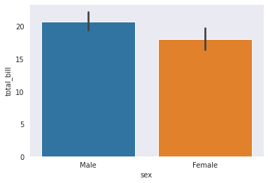

```python
sns.set_style("dark")

sns.barplot(x='sex',y ='total_bill',data=tips)
plt.show()
```

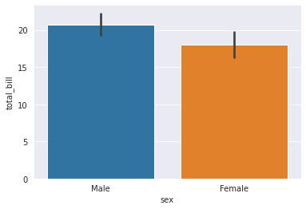

```python
sns.set_style("darkgrid")

sns.barplot(x='sex',y ='total_bill',data=tips)
plt.show()
```

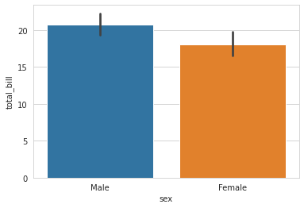

```python
sns.set_style("whitegrid")

sns.barplot(x='sex',y ='total_bill',data=tips)
plt.show()
```

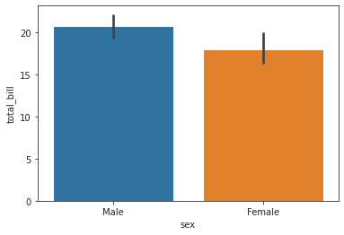

```python
sns.set_style("ticks")

sns.barplot(x='sex',y ='total_bill',data=tips)
plt.show()
```

## Choosing color palettes

Seaborn makes it easy to use colors that are well-suited to the characteristics of your data and your visualization goals.

The default color palette in seaborn is a qualitative palette with ten distinct hues:

```python
sns.color_palette()
```

[output not shown]

These colors have the same ordering as the default matplotlib color palette, "tab10", but they are a bit less intense. Compare:

```python
sns.color_palette("tab10")
```

[output not shown]

### Sequential color palettes

Seaborn also includes four perceptually uniform sequential colormaps: `"rocket"`, `mako"`, `"flare"`, and `"crest"`. The first two have a very wide luminance range and are well suited for applications such as heatmaps, where colors fill the space they are plotted into:

```python
sns.color_palette("rocket")
```

[output not shown]

The Color Brewer library also has some good options for sequential palettes. They include palettes with one primary hue:

```python
sns.color_palette("Blues")
```

[output not shown]

```python
sns.color_palette("YlOrBr")
```

[output not shown]

### Diverging color palettes

These are used for data where both large low and high values are interesting and span a midpoint value (often 0) that should be demphasized.

```python
sns.color_palette("icefire")
```

[output not shown]

```python
sns.color_palette("Spectral")
```

[output not shown]

```python
sns.color_palette("coolwarm")
```

[output not shown]

`Hue` is the component that distinguishes “different colors” in a non-technical sense. It’s property of color that leads to first-order names like “red” and “blue”:

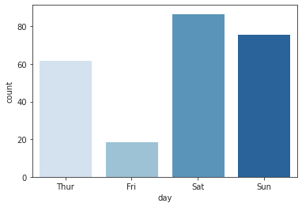

```python
sns.countplot(x='day',data=tips,palette = "Blues")
plt.show()
```

```python
iris = sns.load_dataset('iris')

#lets have a look at the data
iris.head()
```

|  | sepal_length | sepal_width | petal_length | petal_width | species |
| --- | --- | --- | --- | --- | --- |
| 0 | 5.1 | 3.5 | 1.4 | 0.2 | setosa |
| 1 | 4.9 | 3.0 | 1.4 | 0.2 | setosa |
| 2 | 4.7 | 3.2 | 1.3 | 0.2 | setosa |
| 3 | 4.6 | 3.1 | 1.5 | 0.2 | setosa |
| 4 | 5.0 | 3.6 | 1.4 | 0.2 | setosa |

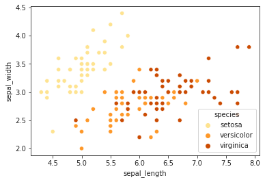

```python
sns.scatterplot(x="sepal_length",y = "sepal_width", hue = 'species', data=iris, palette = "YlOrBr")
plt.show()
```

**Know more about color palettes:**

- https://seaborn.pydata.org/tutorial/color_palettes.html
- https://matplotlib.org/tutorials/colors/colormaps.html